# Unit 1 Mini-Cases

Finance - Course 4 - Risk Management

Aleksandar Gradev

2025-05-07

# Mini-Case 1.1

```r
# load the data
load("C:/WU/SBWL Finance/Course 4 - Risk Management/HW1/Mini_Case_1_1.Rdata")
```

## i)

Assuming you are a risk-averse investor, which investment opportunity would you choose if you have a quadratic utility function?

Risk-averse investors with a quadratic utility function prefer the investment with the lowest risk (variance) for a given level of expected return. In other words, when $E[r]$ is fixed, they choose the project with the lowest volatility.

According to the task, both investment opportunities $A$ and $B$ have equal means (expected returns). Just to be sure, let’s check that.

```r
# calculate means and compare
mean_A <- mean(A)
mean_B <- mean(B)
ifelse(round(mean_A,5) == round(mean_B,5), "Means are equal",
       "Means are not equal")
```

```
## [1] "Means are equal"
```

I will calculate the volatilies of both investment opportunities and choose the one with the lower volatility.

```r
# calculate standard deviations
sd_A <- sd(A)
sd_B <- sd(B)
cat("SD(A):", sd_A,
    "\n\nSD(B):", sd_B)
```

```
## SD(A): 1.570911
##
## SD(B): 1.422751
```

I would choose project B.

## ii)

Assuming you are a risk-averse investor, which investment opportunity would you choose if you use the 5% VaR (based on the quantile of the actual profit/loss distribution) as your risk measure?

Now we have to find the 5th percentile of the payoff distributions of both investment opportunities A and B and choose the one with the smaller VaR.

```r
# sort A in ascending way
ordered_A <- sort(A, decreasing = FALSE)
# find the 5th percentile of A
var_A_0.05 <- quantile(ordered_A, probs = 0.05, type = 6)

# sort b in ascending way
ordered_B <- sort(B, decreasing = FALSE)
# find the 5th percentile of B
var_B_0.05 <- quantile(ordered_B, probs = 0.05, type = 6)

cat("VaR at 5%: \n
A:", -var_A_0.05,
    "  B:", -var_B_0.05)
```

```
## VaR at 5%:
##
## A: 1.473646   B: 1.146987
```

I would choose investment B as it has lower Value at Risk at 5%

## iii)

Assuming you are a risk-averse investor, which investment opportunity would you choose if you use the 0.1% VaR (based on the quantile of the actual profit/loss distribution) as your risk measure?

Now we have to find the 0.1st percentile of the payoff distributions of both investment opportunities A and B and choose the one with the smaller VaR.

```r
# find the 0.1st percentile of A
var_A_0.001 <- quantile(ordered_A, probs = 0.001, type = 6)

# find the 0.1st percentile of A
var_B_0.001 <- quantile(ordered_B, probs = 0.001, type = 6)

cat("VaR at 0.1%: \n
A:", -var_A_0.001,
    "  B:", -var_B_0.001)
```

```
## VaR at 0.1%:
##
## A: 3.681215   B: 6.763344
```

I would choose investment A as it has lower Value at Risk at 0.1%

## iv)

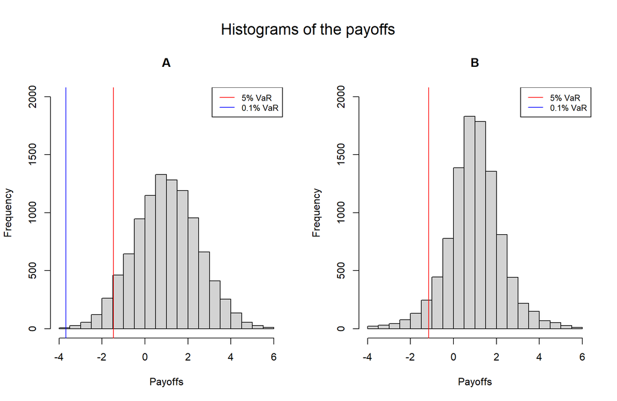

```r
# create subsets with the data between -4 and 6
A_hist <- A[A > -4 & A < 6]
B_hist <- B[B > -4 & B < 6]

# plot both histograms
par(mfrow = c(1, 2), oma = c(0, 0, 3, 0))
hist(A_hist, breaks = 23, xlim = c(-4, 6), ylim = c(0,2000),
     main = "A",
     xlab = "Payoffs")
legend("topright", legend = c("5% VaR", "0.1% VaR"), col = c("red", "blue"),
       lty = 1, cex = 0.8)
abline(v = var_A_0.05, col = 'red')
abline(v = var_A_0.001, col = 'blue')

hist(B_hist, breaks = 23, xlim = c(-4, 6), ylim = c(0,2000),
     main = "B",
     xlab = "Payoffs")
legend("topright", legend = c("5% VaR", "0.1% VaR"), col = c("red", "blue"),
       lty = 1, cex = 0.8)
abline(v = var_B_0.05, col = 'red')
abline(v = var_B_0.001, col = 'blue')

mtext("Histograms of the payoffs", outer = TRUE, cex = 1.5)
```

We can see that the chosen investment opportunity in $i)$ makes sense because A’s histogram is more spread out, meaning that it has higher variance and therefore higher volatility. For $ii)$ we can see that the red line for B is more to the right (less negative) than for A. For $iii)$ we choose A because the blue line for A is more to the right (less negative) than for B (B’s blue line is not even showed on the plot because the -VaR is -6.76 which is even outside the plot).

# Mini-Case 1.2

Consider a value process $W_t$ that follows a Random Walk with drift, i.e.,
$$\frac{\Delta W}{W} = \mu H + \sigma \sqrt{H}
Z,\quad Z \sim \mathcal{N}(0, 1)$$
where $\mu = 8\%$ p.a., $\sigma = 16\%$ p.a., and $W_t = 150$.

## i)

What is the expected return and volatility for a time period of 7 years?

$$E[R_H] = \mu H=0.08*7=0.56$$
$$\sigma_H = \sigma\sqrt{H}=0.16*\sqrt{7}=0.4233$$

## ii)

Consider a realization of $Z$ equal to $-1.6449$. What is the return of $W$ in 7 years?

$$\frac{\Delta W}{W} = \mu H + \sigma \sqrt{H} Z$$
$$\frac{\Delta W}{W} = 0.56 + 0.4233*(-1.6449) = -0.1363$$
The return is -13.63% over 7 years.

## iii)

$$\text{VaR}(\alpha) = W\left( -\mu H - \sigma \sqrt{H} N^{-1}(\alpha)
\right)$$
$$\text{VaR}(0.01) = 150 \left( -0.56 - 0.4233 * (-2.326) \right) =
63.68937$$

There is a 1% probability that the value will drop by 63,69 or more.

# Mini-Case 1.3

I start by downloading the data directly from Yahoo Finance by using the quantmod package.

```r
# download data
library(quantmod)

start_date <- "2015-01-01"
end_date <- "2020-07-02"
today <- "2020-01-01"

getSymbols("SPY", src = "yahoo", from = start_date,
           to = end_date)
```

```
## [1] "SPY"
```

## i)

We have to calculate the daily returns based on the close prices for the entire time period.

```r
# create a new dataframe storing only the close prices
data_3 <- as.data.frame(SPY$SPY.Close)

# calculate daily returns
for (i in 2:nrow(data_3)) {
  data_3$Return[i] <- ((data_3$SPY.Close[i]-data_3$SPY.Close[i-1])
                                          /
                              data_3$SPY.Close[i-1])
}

head(data_3)
```

|  | SPY.Close | Return |
| --- | --- | --- |
| 2015-01-02 | 205.43 | NA |
| 2015-01-05 | 201.72 | -0.018059639 |
| 2015-01-06 | 199.82 | -0.009418966 |
| 2015-01-07 | 202.31 | 0.012461166 |
| 2015-01-08 | 205.90 | 0.017745027 |
| 2015-01-09 | 204.25 | -0.008013569 |

```r
tail(data_3)
```

|  | SPY.Close | Return |
| --- | --- | --- |
| 2020-06-24 | 304.09 | -0.025508706 |
| 2020-06-25 | 307.35 | 0.010720543 |
| 2020-06-26 | 300.05 | -0.023751483 |
| 2020-06-29 | 304.46 | 0.014697563 |
| 2020-06-30 | 308.36 | 0.012809545 |
| 2020-07-01 | 310.52 | 0.007004812 |

## ii)

We have to use the daily returns from 2015-01-01 up to “today” 2020-01-01 to estimate the volatility of the process.

```r
# volatility from 2015-01-01 up to 2020-01-01 (today)
data_3_b <- data_3[rownames(data_3) < today, ]
volatility_3_b <- sd(data_3_b$Return, na.rm = T)

cat("Daily volatility is", volatility_3_b*100, "%")
```

```
## Daily volatility is 0.8509883 %
```

## iii)

We have to estimate the daily 5% VaR (short time horizon) in percent of some fixed notional W based on “past” returns. I’m choosing $W = 10,000$. We have to use the short time horizon formula:

$$\text{VaR} = -W \cdot \sigma \cdot N^{-1}(\alpha)$$

```r
w <- 10000
alpha <- 0.05

# calculate the VaR using the short time horizon formula
var_3_c <- -w * volatility_3_b * qnorm(0.05)

cat("Daily 5% VaR is", (var_3_c / w) * 100,"%")
```

```
## Daily 5% VaR is 1.399751 %
```

## iv)

Now when looking at the period from “today” 2020-01-01 to the “future” 2020-07-01, we have to calculate how often we expect to see more extreme returns than the 5% VaR and compare it to how often we actually saw more extreme returns.

```r
# create a subset with the data from today until the end of the dataset
data_3_d <- data_3[!rownames(data_3) %in% rownames(data_3_b), ]

cat("The number of trading days between 'today' and the 'future' are",
    nrow(data_3_d))
```

```
## The number of trading days between 'today' and the 'future' are 126
```

```r
# create a dummy binary variable showing 1 if the return was worse than the VaR
data_3_d$worse <- ifelse(data_3_d$Return < (-var_3_c / w),
                         1, 0)

cat("We expected to see", ceiling(0.05*(nrow(data_3_d))),
    "days with worse returns than the VaR.",
    "\n\nWe actualy saw",sum(data_3_d$worse), "days with worse returns than the VaR.")
```

```
## We expected to see 7 days with worse returns than the VaR.
##
## We actualy saw 28 days with worse returns than the VaR.
```

## v)

Now we have to plot the return time series.

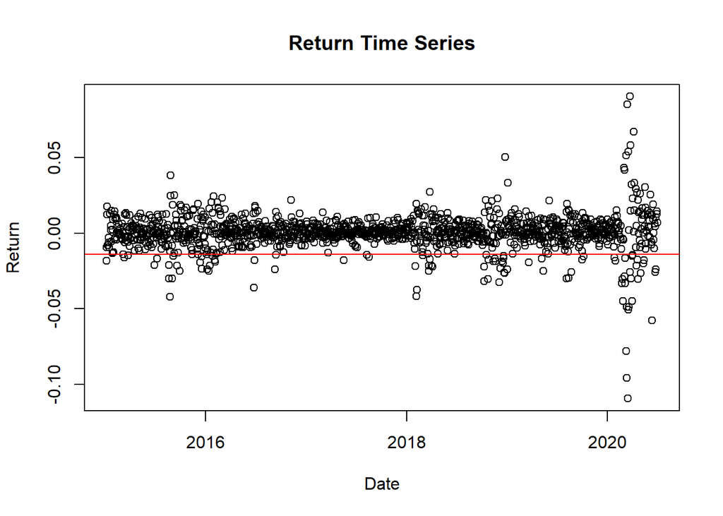

```r
# remove the row with NA
data_3 <- na.omit(data_3)

# plot return time series
plot(as.Date(rownames(data_3)), data_3$Return,
     main = "Return Time Series",
     xlab = "Date",
     ylab = "Return")
# VaR line
abline(h = -var_3_c / w, col = 'red')
```

We can see the returns for each trading day. Most of the points are centered around 0. The red line represents the 5% Value at Risk and all points below it are days were we saw more extreme returns than the 5% VaR.

# Mini-Case 1.4

Consider two value processes $W$ and $Y$ that follow a Random Walk with drift, i.e.,

$$\frac{\Delta W}{W} = \mu_1 H + \sigma_1 \sqrt{H} Z_1, \quad Z_1 \sim
\mathcal{N}(0, 1)$$

and

$$\frac{\Delta Y}{Y} = \mu_2 H + \sigma_2 \sqrt{H} Z_2, \quad Z_2 \sim
\mathcal{N}(0, 1)$$

with correlation coefficient $\rho$.

Both assets have an initial value of 80. The parameters are: - $\mu_1 = 8\%$ p.a., $\sigma_1 = 19\%$ p.a. - $\mu_2 = 11\%$ p.a., $\sigma_2 = 22\%$ p.a.

Assume that you have a portfolio $P$ with an initial value of 80, containing **equal weights** of both assets $W$ and $Y$.

First I start by writing down the portfolio and its drift component.

$$P=0.5W+0.5Y$$

$$\mu_P H=(0.5\mu_W+0.5\mu_Y)H$$
$$\mu_P H=(0.5*0.08+0.5*0.11)*1=0.095$$
The drift component is equal to 9.5%

Now I will derive the volatility of the portfolio by using the VaR given in the task.

$$VaR(0.01) = W \left( -\mu_P H - \sigma_P \sqrt{H} N^{-1}(0.01) \right)$$

$$24.2885 = 80 \left( -0.095 - \sigma_P \sqrt{1}*(-2.326) \right)$$
$$24.2885 = 80 \left( -0.095 + 2.326 \sigma_P \right)$$
$$\frac{24.2885}{80} = -0.095 + 2.326 \sigma_P$$
$$2.326 \sigma_P = 0.3986$$
$$\sigma_P = \frac{0.3986}{2.326} = 0.1714$$
Now I will use the formula for standard deviation of a portfolio consisting of 2 assets.

$$\sigma_P = \sqrt{w_X^2 \sigma_X^2 + w_Y^2 \sigma_Y^2 + 2\rho w_X w_Y
\sigma_X \sigma_Y}.$$
$$0.1714= \sqrt{0.5^2 *0.19^2 + 0.5^2 *0.22^2 + 2*\rho*0.5*0.5*0.19*0.22}$$
$$0.02937796= 0.009025 + 0.0121 + 0.0209\rho$$
$$\rho = \frac{0.00825296}{0.0209} = 0.3948785$$

# Mini-Case 1.5

Assume that you own 6,000 shares of Erste Bank Group (EBS), 4,000 shares of Verbund (VER), 2,000 shares of Voestalpine (VOE), 1000 shares of Andritz (ANDR) and 5,000 shares of OMV (OMV).

## i)

We have to estimate the variance-covariance matrix based on the historical time series.

```r
# load the data
load("C:/WU/SBWL Finance/Course 4 - Risk Management/HW1/Mini_Case_1_5.Rdata")

# store the number of shares held
shares_vector <- as.vector(c(6000,4000,2000,1000,5000))
names(shares_vector) <- c("EBS","VER","VOE","ANDR","OMV")

returns <- prices

# calculate daily returns for each company
for (i in 2:6) {
  for (j in 2:nrow(prices)) {
    returns[j,i] <- (prices[j,i]-prices[j-1,i])/prices[j-1,i]
  }
}
returns <- returns[-1, ]

# calculate var-cov matrix
sigma <- var(returns[,2:6])
print(sigma)
```

```
##               EBS          VER          VOE         ANDR          OMV
## EBS  0.0004134821 0.0001193642 0.0001788817 0.0001273446 0.0002788246
## VER  0.0001193642 0.0004658541 0.0001148383 0.0001051724 0.0001927784
## VOE  0.0001788817 0.0001148383 0.0003308351 0.0001297075 0.0002242139
## ANDR 0.0001273446 0.0001051724 0.0001297075 0.0003110165 0.0001593803
## OMV  0.0002788246 0.0001927784 0.0002242139 0.0001593803 0.0005456690
```

## ii)

We have to calculate the daily 0.5% VaR using the delta-normal assumption. We need to calculate the delta vector storing the position values by multiplying the shares own in each stock to the current (latest) prices of the stocks. W will then be the sum of the values of all positions.

```r
# store last prices as current prices
current_prices <- as.matrix(prices[nrow(prices), 2:6])

# calculate vector storing the position values
delta <- shares_vector*current_prices
print(delta)
```

```
##           EBS      VER      VOE     ANDR      OMV
## 1253 234611.7 391535.6 60242.66 43488.21 239256.3
```

```r
# total portofolio value
w <- sum(delta)

# portfolio sd
volatility <- sqrt(as.vector(delta)%*%as.matrix(sigma)%*%t(t(as.vector(delta))))

# portfolio VaR
var <- -volatility * qnorm(0.005)

cat("The daily 0.5% VaR is", var)
```

```
## The daily 0.5% VaR is 40207.92
```

# Mini-Case 1.6

Now we assume that you own 7,000 shares of Erste Bank Group (EBS), 12,000 shares of Verbund (VER), 7,000 shares of Voestalpine (VOE), 4,000 shares of Andritz (ANDR) and 2,000 shares of OMV (OMV). We need to calculate the VaR for a time horizon of one trading day using the historical simulation approach for alphas 5% and 1%, respectively.

```r
# load the prices data
load("C:/WU/SBWL Finance/Course 4 - Risk Management/HW1/Mini_Case_1_6.Rdata")

# store the number of shares held in each stock
shares_vector <- as.vector(c(7000,12000,7000,4000,2000))
names(shares_vector) <- c("EBS","VER","VOE","ANDR","OMV")

# calculate daily returns for all stocks and store the returns in a new data frame
returns <- prices
for (i in 2:6) {
  for (j in 2:nrow(prices)) {
    returns[j,i] <- (prices[j,i]-prices[j-1,i])/prices[j-1,i]
  }
}
returns <- returns[-1, ]

# store the last price as current price
current_prices <- as.matrix(prices[nrow(prices), 2:6])

# create and empty column to store the portfolio value of each case
returns$portfolio <- rep(NA, nrow(returns))

# calculate the portfolio value for each case
for (i in 1:nrow(returns)) {
  returns$portfolio[i] <- sum(
    shares_vector["EBS"] * (1 + returns$EBS[i]) * current_prices[, "EBS"],
    shares_vector["VER"] * (1 + returns$VER[i]) * current_prices[, "VER"],
    shares_vector["VOE"] * (1 + returns$VOE[i]) * current_prices[, "VOE"],
    shares_vector["ANDR"] * (1 + returns$ANDR[i]) * current_prices[, "ANDR"],
    shares_vector["OMV"]  * (1 + returns$OMV[i])  * current_prices[, "OMV"]
  )
}

# calculate current values of the stock position as well as the total portfolio
current_values <- current_prices*shares_vector
current_portfolio <- sum(current_values)

# create a variable storing the profit/loss
returns$pnl <- returns$portfolio-current_portfolio

# find the 5th and the 1st percentile value for VaRs
var_0.05 <- quantile(returns$pnl, probs = 0.05, type = 6)
var_0.01 <- quantile(returns$pnl, probs = 0.01, type = 6)

cat("VaR at 0.5%: \n",
    -var_0.05,
    "\n\nVaR at 0.1%: \n", -var_0.01)
```

```
## VaR at 0.5%:
##  44561.27
##
## VaR at 0.1%:
##  92723.38
```

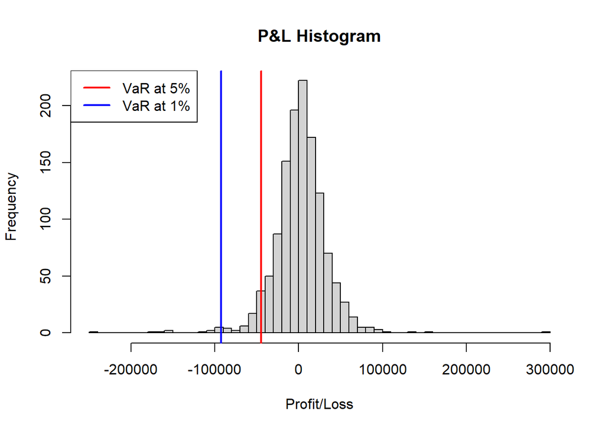

```r
# plot profit/loss histogram
options(scipen = 10)
hist(returns$pnl, breaks = 60,
     main = "P&L Histogram", xlab = "Profit/Loss")
legend("topleft", legend = c("VaR at 5%", "VaR at 1%"),
       col = c("red", "blue"),lty = 1, lwd = 2)
abline(v = var_0.05, col = 'red', lwd = 2)
abline(v = var_0.01, col = 'blue', lwd = 2)
```